# Ayudantía 7 - ML para Negocios

12 de octubre del 2022

# Introducción

Bienvenid@s a la séptima ayudantía de EAA3707 - Machine Learning para Negocios. En la ayudantía veremos:

1. Support Vector Machines (SVM)
2. Kernel no lineales

Antes de comenzar, cargamos las librerías que utilizaremos durante la ayudantía.

```r
library(tidyverse)
library(tidymodels)
library(ggcorrplot)
library(patchwork)
library(kernlab)


# Para obtener resultados reproducibles
set.seed(219)
```

Les recuerdo los libros que les recomiendo para aprender de R:

- **Hands-On Programming with R**: disponible [acá](https://rstudio-education.github.io/hopr/). Útil para recordar cosas básicas de R.
- **Advanced R**: disponible [acá](https://adv-r.hadley.nz/). Para aprender R avanzado (realmente avanzado), si es que están interesados en entender cómo funciona R por detrás.
- **R for Data Science**: disponible [acá](https://r4ds.had.co.nz/). Bueno para aprender y aplicar Data Science de manera rápida, además de ser uno de los libros guía para aprender acerca de los paquetes de tidyverse.
- **RMarkdown Cookbook**: disponible [acá](https://bookdown.org/yihui/rmarkdown-cookbook/). Útil para aprender lo básico de RMarkdown.
- **RMarkdown: The Definitive Guide**: disponible [acá](https://bookdown.org/yihui/rmarkdown/). Útil para aprender cosas avanzadas de RMarkdown.
- **Tidy Modeling with R**: disponible [acá](https://www.tmwr.org/). Recomendado para aprender del ecosistema tidymodels. Tiene también un capítulo pequeño de tidyverse con lo justo y necesario.

# Support Vector Machines

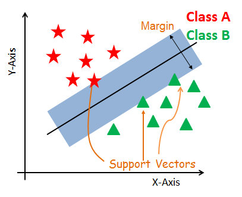

SVM

Las Máquinas de Vector Soporte (SVM) son un modelo de aprendizaje supervisado el cual, a partir de hiperplanos, separa de forma óptima los puntos de una clase y otra. El concepto fundamental es el de “separación óptima”, donde se busca el hiperplano que tenga la máxima distancia (margen) con los puntos que estén más cerca de él mismo.

**Nota**: SVM también puede ser utilizado para regresión.

Es importante recordar que un hiperplano p-dimensional está dado por
$$h_w(x) = w^tx + b = 0$$

donde $w, x \in \mathbb{R}^p$. Estos hiperplanos dividen el espacio en dos, uno con $h_w(x) > 0$ y otro con $h_w(x) < 0$, lo cual al unir con los $x$ tal que $h_w(x) = 0$ nos entrega el espacio original.

¿Qué es lo que buscamos entonces al ajustar el modelo? lo que buscamos es justamente encontrar este hiperplano $h_w(x)$ que separe de manera “óptima”. Por ejemplo, en el caso binario de clasificación, nos interesaría encontrar el hiperplano tal que $h_w(x_i) \geq 0$ para una categoría y $h_w(x_i) < 0$ para otra categoría. Es importante notar que lo anterior no siempre es posible de manera perfecta, y en el caso que sí lo sea diremos que el problema es **perfectamente separable**.

**Nota**: cuando hablamos de “encontrar” el hiperplano lo que buscamos entonces es $w$ y $b$.

En el caso anterior, si denotamos las categorías por $\pm 1$ entonces queremos encontrar el hiperplano tal que $y_ih_w(x_i) \geq 0$ para todo $i = 1, ...,n$. Ahora, pueden existir muchos hiperplanos que cumplan lo anterior, así que elegimos el “mejor” como el que maximice el margen con respecto a los puntos de las clases, lo cual se representa a través del problema de optimización dado por

$$\min_{w, b} \frac{||w||^2}{2}, \quad \text{sujeto a} \;\; y_i(w^tx + b)
\geq 1$$

Ahora, ¿qué pasa si los datos no son linealmente separables?. Para acomodar el modelo anterior a este caso se introducen las variables **slack** $\xi_i$ obteniendo el nuevo problema de optimización dado por

$$\min_{w, b, \xi}\frac{||w||^2}{2} + C\sum_{i=1}^n \xi_i$$

sujeto a $y_i(w^Tx_i + b) \geq 1 - \xi_i$, $\xi_i \geq 0$.

# Aplicación - Predicción de quiebra

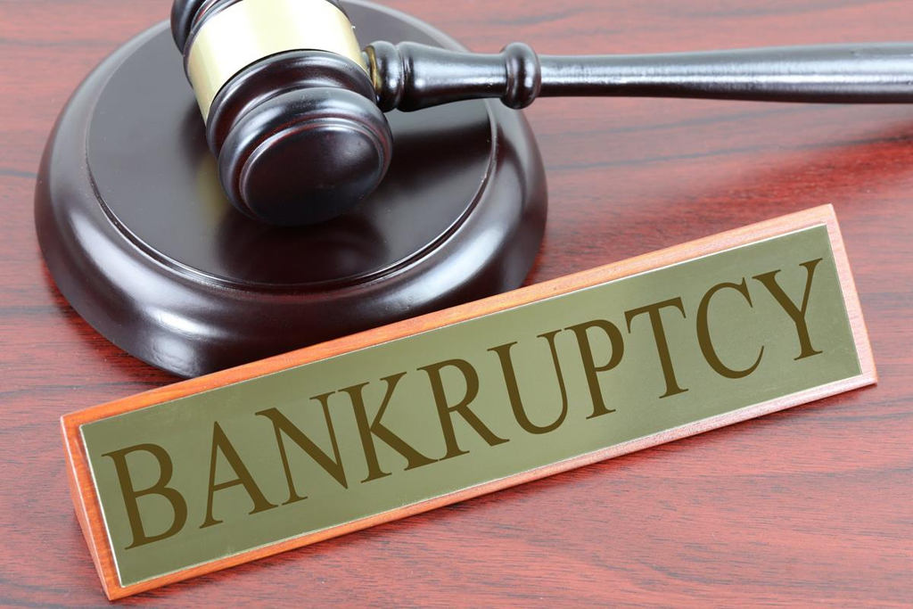

Para aplicar de manera práctica el modelo SVM, utilizaremos la base de datos `bankruptcy.csv`, obtenida del [repositorio](https://archive-beta.ics.uci.edu/ml/datasets/taiwanese+bankruptcy+prediction#Abstract) de datos de UC Irvine.

Esta base de datos contiene información de compañías taiwanesas entre los años 1999 y 2009 como el ROA, ventas netas, tasas, valor neto, etc., así como la definición como compañía en bancarrota o no según las regulaciones de la Bolsa de Valores de Taiwán. Nos gustaría entonces predecir si una empresa, dada sus actuales características, está en riesgo o no.

## Análisis exploratorio

En primer lugar, cargamos nuestros datos.

```r
bankruptcy <- read_csv(here("Ayudantía 6", "bankruptcy.csv"), show_col_types = FALSE)
head(bankruptcy, 8)
```

| Bankrupt? | ROA(C) before interest and depreciation before interest | ROA(A) before interest and % after tax | ROA(B) before interest and depreciation after tax | Operating Gross Margin | Realized Sales Gross Margin | Operating Profit Rate | Pre-tax net Interest Rate | After-tax net Interest Rate | Non-industry income and expenditure/revenue | Continuous interest rate (after tax) | Operating Expense Rate | Research and development expense rate | Cash flow rate | Interest-bearing debt interest rate | Tax rate (A) | Net Value Per Share (B) | Net Value Per Share (A) | Net Value Per Share (C) | Persistent EPS in the Last Four Seasons | Cash Flow Per Share | Revenue Per Share (Yuan ¥) | Operating Profit Per Share (Yuan ¥) | Per Share Net profit before tax (Yuan ¥) | Realized Sales Gross Profit Growth Rate | Operating Profit Growth Rate | After-tax Net Profit Growth Rate | Regular Net Profit Growth Rate | Continuous Net Profit Growth Rate | Total Asset Growth Rate | … |
| --- | --- | --- | --- | --- | --- | --- | --- | --- | --- | --- | --- | --- | --- | --- | --- | --- | --- | --- | --- | --- | --- | --- | --- | --- | --- | --- | --- | --- | --- | --- |
| 1 | 0.3705943 | 0.4243894 | 0.4057498 | 0.6014572 | 0.6014572 | 0.9989692 | 0.7968871 | 0.8088094 | 0.3026464 | 0.7809849 | 1.256969e-04 | 0.00e+00 | 0.4581431 | 0.0007250725 | 0.000000 | 0.1479499 | 0.1479499 | 0.1479499 | 0.1691406 | 0.3116644 | 0.017559780 | 0.09592053 | 0.1387362 | 0.02210228 | 0.8481950 | 0.6889795 | 0.6889795 | 0.2175354 | 4.98e+09 | … |
| 1 | 0.4642909 | 0.5382141 | 0.5167300 | 0.6102351 | 0.6102351 | 0.9989460 | 0.7973802 | 0.8093007 | 0.3035564 | 0.7815060 | 2.897851e-04 | 0.00e+00 | 0.4618673 | 0.0006470647 | 0.000000 | 0.1822511 | 0.1822511 | 0.1822511 | 0.2089439 | 0.3181368 | 0.021144335 | 0.09372201 | 0.1699179 | 0.02208017 | 0.8480879 | 0.6896929 | 0.6897017 | 0.2176196 | 6.11e+09 | … |
| 1 | 0.4260713 | 0.4990188 | 0.4722951 | 0.6014500 | 0.6013635 | 0.9988574 | 0.7964034 | 0.8083875 | 0.3020352 | 0.7802839 | 2.361297e-04 | 2.55e+07 | 0.4585206 | 0.0007900790 | 0.000000 | 0.1779107 | 0.1779107 | 0.1937129 | 0.1805805 | 0.3071019 | 0.005944008 | 0.09233776 | 0.1428033 | 0.02276010 | 0.8480940 | 0.6894627 | 0.6894697 | 0.2176013 | 7.28e+09 | … |
| 1 | 0.3998440 | 0.4512647 | 0.4577333 | 0.5835411 | 0.5835411 | 0.9986997 | 0.7969670 | 0.8089656 | 0.3033495 | 0.7812410 | 1.078888e-04 | 0.00e+00 | 0.4657054 | 0.0004490449 | 0.000000 | 0.1541865 | 0.1541865 | 0.1541865 | 0.1937222 | 0.3216736 | 0.014368468 | 0.07776240 | 0.1486028 | 0.02204607 | 0.8480055 | 0.6891095 | 0.6891095 | 0.2175682 | 4.88e+09 | … |
| 1 | 0.4650222 | 0.5384322 | 0.5222978 | 0.5987835 | 0.5987835 | 0.9989731 | 0.7973661 | 0.8093037 | 0.3034750 | 0.7815500 | 7.890000e+09 | 0.00e+00 | 0.4627463 | 0.0006860686 | 0.000000 | 0.1675024 | 0.1675024 | 0.1675024 | 0.2125366 | 0.3191625 | 0.029689792 | 0.09689765 | 0.1684115 | 0.02209591 | 0.8482582 | 0.6896969 | 0.6896969 | 0.2176256 | 5.51e+09 | … |
| 1 | 0.3886803 | 0.4151766 | 0.4191338 | 0.5901714 | 0.5902507 | 0.9987581 | 0.7969032 | 0.8087706 | 0.3031158 | 0.7810691 | 1.571500e-04 | 0.00e+00 | 0.4658615 | 0.0007160716 | 0.000000 | 0.1555771 | 0.1555771 | 0.1555771 | 0.1744351 | 0.3253873 | 0.018104270 | 0.07808810 | 0.1388115 | 0.02156494 | 0.8479828 | 0.6891051 | 0.6891775 | 0.2175664 | 6.08e+08 | … |
| 0 | 0.3909228 | 0.4457043 | 0.4361583 | 0.6199498 | 0.6199498 | 0.9989931 | 0.7970119 | 0.8089604 | 0.3028144 | 0.7811801 | 3.984834e-04 | 7.30e+08 | 0.4610201 | 0.0008050805 | 0.000000 | 0.1588218 | 0.1588218 | 0.1588218 | 0.1614825 | 0.3166867 | 0.030914893 | 0.09991043 | 0.1289448 | 0.02211225 | 0.8483225 | 0.6885899 | 0.6885899 | 0.2176045 | 5.72e+09 | … |
| 0 | 0.5083606 | 0.5709224 | 0.5590770 | 0.6017383 | 0.6017167 | 0.9990090 | 0.7974488 | 0.8093615 | 0.3035446 | 0.7816215 | 9.000000e+09 | 5.09e+07 | 0.4670240 | 0.0006300630 | 0.157607 | 0.1769837 | 0.1769837 | 0.1769837 | 0.2252056 | 0.3241140 | 0.042560915 | 0.10479603 | 0.1804625 | 0.02211432 | 0.8480822 | 0.6895352 | 0.6895352 | 0.2176332 | 6.63e+09 | … |

Lo primero que podemos notar es que la variable `Bankrupt?` categórica está como numérica, por lo que la pasamos a factor (de pasada también le cambiamos el nombre)

```r
bankruptcy <- bankruptcy %>%
  dplyr::rename(bankrupt = `Bankrupt?`) %>%
  dplyr::mutate(bankrupt = factor(bankrupt, levels = c("1", "0"),
                                  labels = c("Yes", "No")))
glimpse(bankruptcy)
```

```
## Rows: 6,819
## Columns: 96
## $ bankrupt                                                  <fct> Yes, Yes, Ye…
## $ `ROA(C) before interest and depreciation before interest` <dbl> 0.3705943, 0…
## $ `ROA(A) before interest and % after tax`                  <dbl> 0.4243894, 0…
## $ `ROA(B) before interest and depreciation after tax`       <dbl> 0.4057498, 0…
## $ `Operating Gross Margin`                                  <dbl> 0.6014572, 0…
## $ `Realized Sales Gross Margin`                             <dbl> 0.6014572, 0…
## $ `Operating Profit Rate`                                   <dbl> 0.9989692, 0…
## $ `Pre-tax net Interest Rate`                               <dbl> 0.7968871, 0…
## $ `After-tax net Interest Rate`                             <dbl> 0.8088094, 0…
## $ `Non-industry income and expenditure/revenue`             <dbl> 0.3026464, 0…
## $ `Continuous interest rate (after tax)`                    <dbl> 0.7809849, 0…
## $ `Operating Expense Rate`                                  <dbl> 1.256969e-04…
## $ `Research and development expense rate`                   <dbl> 0.00e+00, 0.…
```

[output cut: 83 more lines]

Otra cosa importante es notar la gran diferencia de observaciones entre ambas clases, lo cual podemos ver a continuación:

```r
table(bankruptcy$bankrupt)
```

```
##
##  Yes   No
##  220 6599
```

Por último, y **solo** para facilitar un poco la ayudantía, elegiré al azar algunas de las columnas de la base de datos para utilizar.

```r
bankruptcy <- bankruptcy[, c(1, 2, 5, 9, 14, 24, 29, 33, 48, 51, 56, 66, 72)]
```

Ya con esto podemos ver, por ejemplo, un gráfico de correlación entre las variables predictoras, o la distribución de éstas separando por la clase.

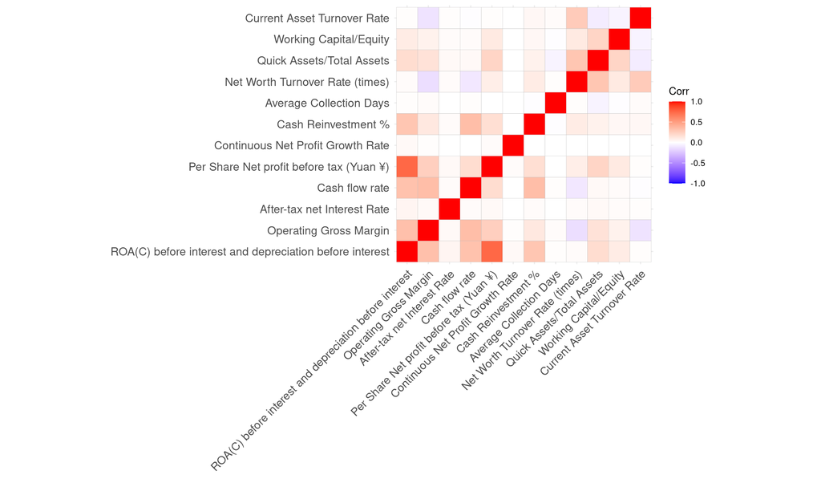

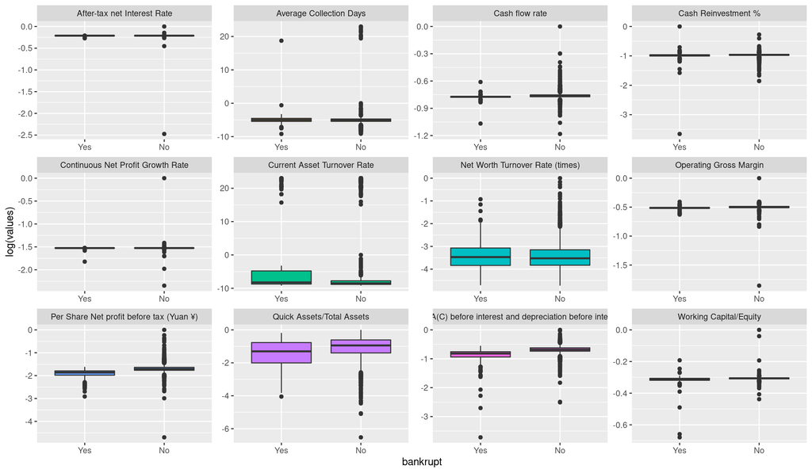

## Modelo de clasificación

Como lo hemos hecho en las ayudantías pasadas, realizamos los primeros pasos típicos con tidymodels en el código a continuación. Es importante que para esta ayudantía utilizaremos solo `svm_linear`, y para la siguiente exploraremos las otras opciones.

Para la especificación del modelo, tunearemos el parámetro de costo $C$ que aparece más arriba en el problema de optimización.

```r
# 1. División de los datos
bankruptcy_split <- rsample::initial_split(
  data = bankruptcy,
  strata = bankrupt
)

bankruptcy_train <- rsample::training(bankruptcy_split)
bankruptcy_test <- rsample::testing(bankruptcy_split)
bankruptcy_cv <- rsample::vfold_cv(bankruptcy_train, v = 5, strata = bankrupt)

# 2. Especificación del modelo
bank_model <- parsnip::svm_linear(cost = tune()) %>%
  set_engine("kernlab") %>%
  set_mode("classification")

# 3. Especificación de la receta
bank_recipe <- recipes::recipe(bankrupt ~ ., data = bankruptcy_train) %>%
  step_normalize(all_predictors())

# 4. Modelo
bank_wf <-
  workflows::workflow() %>%
  add_model(bank_model) %>%
  add_recipe(bank_recipe)
```

### Tuning

```r
cost()
```

```
## Cost (quantitative)
## Transformer: log-2 [1e-100, Inf]
## Range (transformed scale): [-10, 5]
```

```r
bank_wf %>% extract_parameter_dials("cost")
```

```
## Cost (quantitative)
## Transformer: log-2 [1e-100, Inf]
## Range (transformed scale): [-10, 5]
```

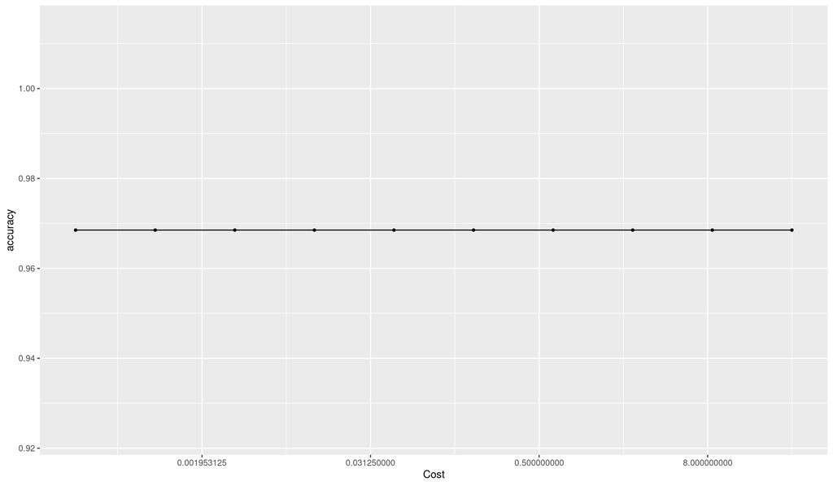

```r
# Cambio en los valores
c_par <- cost(range = c(-12, 5)) %>% grid_regular(levels = 10)
metrics <- yardstick::metric_set(accuracy)

# Grilla
bank_tune <-
  bank_wf %>%
  tune_grid(
    bankruptcy_cv,
    grid = c_par,
    metrics = metrics
  )

autoplot(bank_tune)
```

Algo importante de lo anterior es que notamos que el **accuracy** se mantiene constante, en un valor bastante alto, al cambiar el hiperparámetro de costo. ¿Es esto un indicador de que el modelo está funcionando bien?

```r
# Vemos el parámetro del mejor modelo
select_best(bank_tune, metric = "accuracy")
```

| cost | .config |
| --- | --- |
| 0.0002441406 | Preprocessor1_Model01 |

```r
# Obtenemos el fit final
bank_f_wf <-
  bank_wf %>%
  finalize_workflow(select_best(bank_tune, metric = "accuracy"))
bank_f_wf
```

```
## ══ Workflow ════════════════════════════════════════════════════════════════════
## Preprocessor: Recipe
## Model: svm_linear()
##
## ── Preprocessor ────────────────────────────────────────────────────────────────
## 1 Recipe Step
##
## • step_normalize()
##
## ── Model ───────────────────────────────────────────────────────────────────────
## Linear Support Vector Machine Model Specification (classification)
##
## Main Arguments:
##   cost = 0.000244140625
##
## Computational engine: kernlab
```

```r
# Ajustamos y predecimos
bank_fit <-
  bank_f_wf %>%
  fit(bankruptcy_train)
bank_predictions <-
  bank_fit %>%
  predict(new_data = bankruptcy_test) %>%
  dplyr::bind_cols(bankruptcy_test) %>%
  dplyr::select(bankrupt, .pred_class)
head(bank_predictions, 10)
```

| bankrupt | .pred_class |
| --- | --- |
| Yes | No |
| No | No |
| No | No |
| No | No |
| No | No |
| No | No |
| No | No |
| No | No |
| No | No |
| No | No |

Notamos algo raro…

```r
table(bank_predictions$.pred_class)
```

```
##
##  Yes   No
##    0 1705
```

Obviamente conseguimos un accuracy muy alto, ya que el modelo predijo que ninguna compañía está en bancarrota, y como éstas son más…

Así, mejor veamos la matriz de confusión.

```r
conf_mat(
  data = bank_predictions,
  truth = bankrupt,
  estimate = .pred_class
)
```

```
##           Truth
## Prediction  Yes   No
##        Yes    0    0
##        No    59 1646
```

En este caso hay dos métricas que son más de interés: **precision** y **recall**. Juntamos todo lo anterior en el código a continuación, utilizando ahora estas métricas.

```r
set.seed(219)

# 1. División de los datos
bankruptcy_split <- rsample::initial_split(
  data = bankruptcy,
  strata = bankrupt
)

bankruptcy_train <- rsample::training(bankruptcy_split)
bankruptcy_test <- rsample::testing(bankruptcy_split)
bankruptcy_cv <- rsample::vfold_cv(bankruptcy_train, v = 5, strata = bankrupt)

# 2. Especificación del modelo
bank_model <-
  parsnip::svm_linear(cost = tune()) %>%
  set_engine("kernlab") %>%
  set_mode("classification")

# 3. Especificación de la receta
bank_recipe <-
  recipes::recipe(bankrupt ~ ., data = bankruptcy_train) %>%
  step_normalize(all_predictors())

# 4. Modelo
bank_wf <-
  workflows::workflow() %>%
  add_model(bank_model) %>%
  add_recipe(bank_recipe)

# Cambio en los valores
c_par <- cost(range = c(-12, 5)) %>% grid_regular(levels = 5)
metrics <- yardstick::metric_set(precision, recall)

# Grilla
bank_tune <-
  bank_wf %>%
  tune_grid(
    bankruptcy_cv,
    grid = c_par,
    metrics = metrics
  )
```

```
## ! Fold1: internal:
##   While computing binary `precision()`, no predicted events were detecte...
##   Precision is undefined in this case, and `NA` will be returned.
##   Note that 32 true event(s) actually occured for the problematic event ...
```

```
## ! Fold2: internal:
##   While computing binary `precision()`, no predicted events were detecte...
##   Precision is undefined in this case, and `NA` will be returned.
##   Note that 36 true event(s) actually occured for the problematic event ...
```

```
## ! Fold3: internal:
##   While computing binary `precision()`, no predicted events were detecte...
##   Precision is undefined in this case, and `NA` will be returned.
##   Note that 32 true event(s) actually occured for the problematic event ...
```

```
## ! Fold4: internal:
##   While computing binary `precision()`, no predicted events were detecte...
##   Precision is undefined in this case, and `NA` will be returned.
##   Note that 33 true event(s) actually occured for the problematic event ...
```

```
## ! Fold5: internal:
##   While computing binary `precision()`, no predicted events were detecte...
##   Precision is undefined in this case, and `NA` will be returned.
##   Note that 28 true event(s) actually occured for the problematic event ...
```

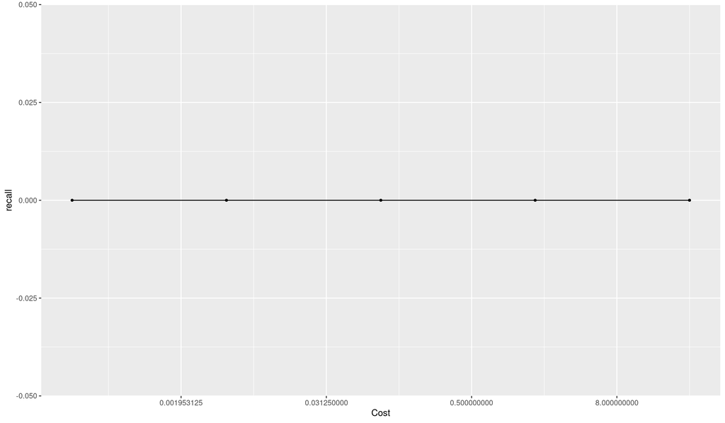

```r
autoplot(bank_tune)
```

```r
# Vemos el parámetro del mejor modelo
select_best(bank_tune, metric = "recall")
```

| cost | .config |
| --- | --- |
| 0.0002441406 | Preprocessor1_Model1 |

```r
# Obtenemos el fit final
bank_f_wf <-
  bank_wf %>%
  finalize_workflow(select_best(bank_tune, metric = "precision"))
bank_f_wf
```

```
## ══ Workflow ════════════════════════════════════════════════════════════════════
## Preprocessor: Recipe
## Model: svm_linear()
##
## ── Preprocessor ────────────────────────────────────────────────────────────────
## 1 Recipe Step
##
## • step_normalize()
##
## ── Model ───────────────────────────────────────────────────────────────────────
## Linear Support Vector Machine Model Specification (classification)
##
## Main Arguments:
##   cost = 0.000244140625
##
## Computational engine: kernlab
```

```r
# Ajustamos y predecimos
bank_fit <-
  bank_f_wf %>%
  fit(bankruptcy_train)
bank_predictions <-
  bank_fit %>%
  predict(new_data = bankruptcy_test) %>%
  dplyr::bind_cols(bankruptcy_test) %>%
  dplyr::select(bankrupt, .pred_class)
head(bank_predictions, 10)
```

| bankrupt | .pred_class |
| --- | --- |
| Yes | No |
| No | No |
| No | No |
| No | No |
| No | No |
| No | No |
| No | No |
| No | No |
| No | No |
| No | No |

```r
conf_mat(
  data = bank_predictions,
  truth = bankrupt,
  estimate = .pred_class
)
```

```
##           Truth
## Prediction  Yes   No
##        Yes    0    0
##        No    59 1646
```

# SVM no lineal

En la sección anterior asumimos que los datos son linealmente separables, o que al menos podíamos utilizar las variables slack tal que nos quedaran de esa manera. Dado los resultados obtenidos en la parte aplicada anterior, es posible que no existían maneras óptimas de incluir estas variables para así obtener una solución.

¿Qué alternativas tenemos entonces?: lo que podemos hacer es encontrar un límite de decisión que no sea lineal.

La forma en que hacemos lo anterior es transformando los datos de entrada en un espacio de mayor dimensión en el cual sí podamos encontrar un separador lineal. El problema de lo anterior es que el costo de resolver el problema de optimización en este nuevo espacio es demasiado alto.

De todas maneras, es posible mostrar que el nuevo problema de optimización es equivalente al anterior, pero que ahora se cambian los productos punto $x_i^Tx_j$ por los productos punto en el nuevo espacio $\phi(x_i)^T\phi(x_j)$. ¿Qué nos dice esto?, esto nos dice que lo único que necesitamos realmente para resolver el problema es una función que dado dos valores $x_i$ y $x_j$ nos entregue el producto punto en el nuevo espacio, y esta función es la que se denomina **kernel**, denotada por

$$K(x_i, x_j) = \phi(x_i)^T\phi(x_j)$$

En nuestro caso veremos dos kernels que están implementados en `parsnip`: el polinomial y el gaussiano (también conocido como RBF de Radial Basis Functions)

## Modelamiento

En nuestro caso utilizaremos el kernel gaussiano para mostrar las diferencias con el caso lineal. Definimos el modelo igual que antes, solo que ahora usamos `svm_rbf`. En este caso el único motor que acepta `parsnip` es `kernlab` y considera dos hiperparámetros: el costo $C$ y el parámetro del kernel $\sigma$.

```r
set.seed(219)

# 1. División de los datos
bankruptcy_split <- rsample::initial_split(
  data = bankruptcy,
  strata = bankrupt
)

bankruptcy_train <- rsample::training(bankruptcy_split)
bankruptcy_test <- rsample::testing(bankruptcy_split)
bankruptcy_cv <- rsample::vfold_cv(bankruptcy_train, v = 5, strata = bankrupt)

# 2. Especificación del modelo
bank_model <- parsnip::svm_rbf(cost = tune(), rbf_sigma = tune()) %>%
  set_engine("kernlab") %>%
  set_mode("classification")

# 3. Especificación de la receta
bank_recipe <- recipes::recipe(bankrupt ~ ., data = bankruptcy_train) %>%
  step_normalize(all_predictors())

# 4. Modelo
bank_wf <-
  workflows::workflow() %>%
  add_model(bank_model) %>%
  add_recipe(bank_recipe)
```

### Tuning de los hiperparámetros

En las ayudantías pasadas hemos realizado el tuning de los hiperparámetros de la misma manera: con grillas regulares. Es importante notar que esta no es la única forma, y que existen otras cada una con sus ventajas y desventajas.

En particular, existen dos modos: búsqueda en grillas y búsqueda iterativa. En este caso nos enfocaremos en la búsqueda en grilla, la cual tiene subdivisiones en regulares e irregulares.

Veamos por ejemplo en nuestro caso las diferencias:

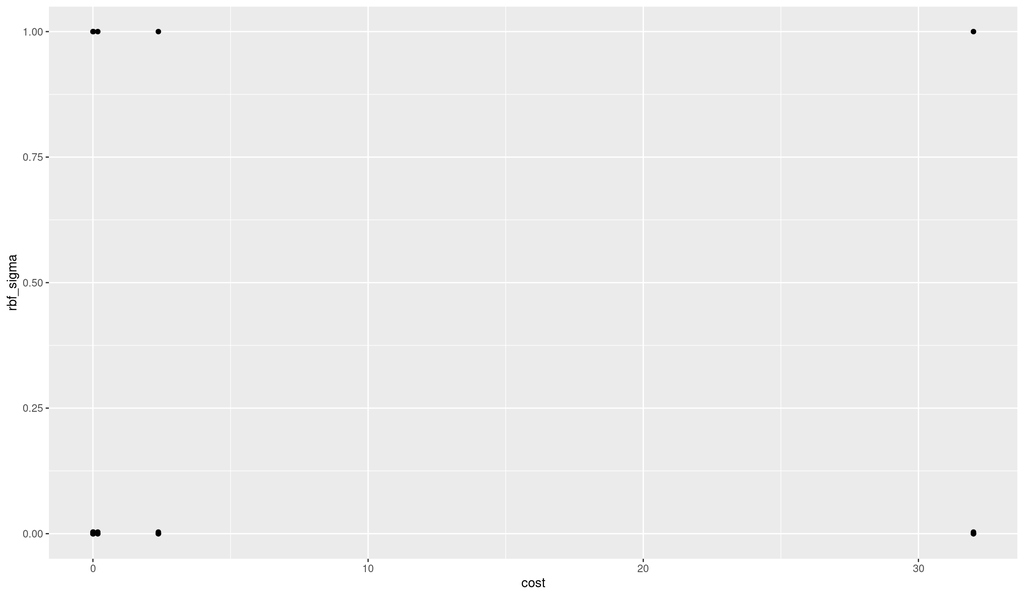

```r
params_svm <- parameters(cost(), rbf_sigma())

# Grilla regular
regular <- grid_regular(params_svm, levels = c(5, 5))

ggplot(regular, aes(x = cost, y = rbf_sigma)) +
  geom_point()
```

```r
## Recordar que las escalas son transformadas
cost()
```

```
## Cost (quantitative)
## Transformer: log-2 [1e-100, Inf]
## Range (transformed scale): [-10, 5]
```

```r
rbf_sigma()
```

```
## Radial Basis Function sigma (quantitative)
## Transformer: log-10 [1e-100, Inf]
## Range (transformed scale): [-10, 0]
```

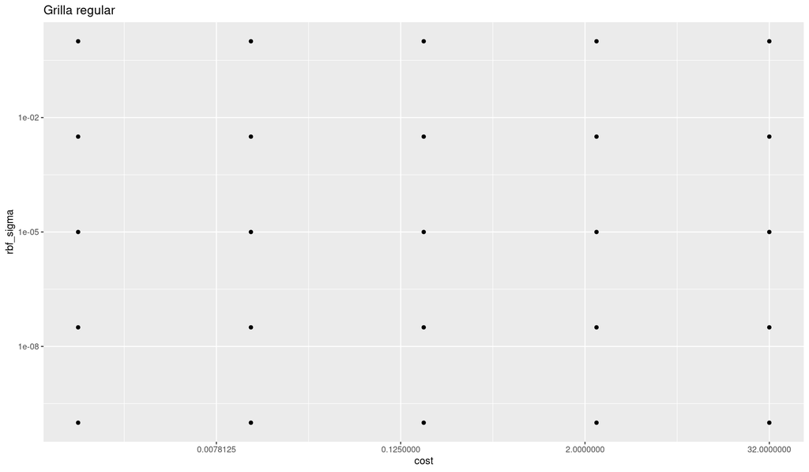

```r
ggplot(regular, aes(x = cost, y = rbf_sigma)) +
  geom_point() +
  scale_y_log10() +
  scale_x_continuous(trans = "log2") +
  labs(title = "Grilla regular")
```

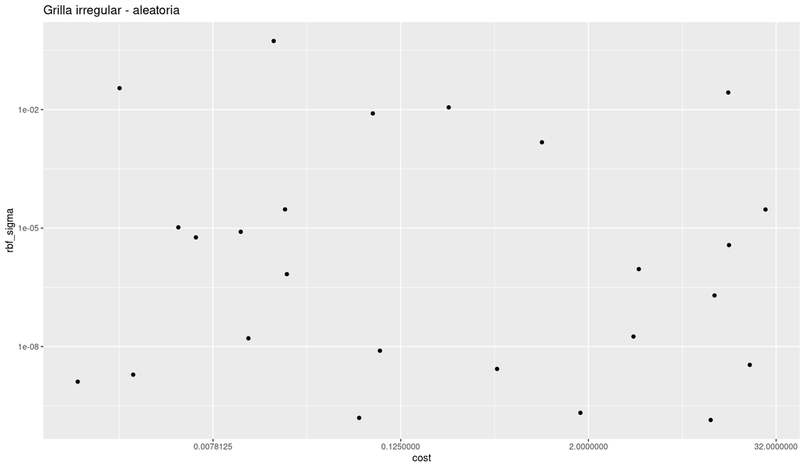

```r
# Grilla aleatoria
random <- grid_random(params_svm, size = 25)

ggplot(random, aes(x = cost, y = rbf_sigma)) +
  geom_point() +
  scale_y_log10() +
  scale_x_continuous(trans = "log2") +
  labs(title = "Grilla irregular - aleatoria")
```

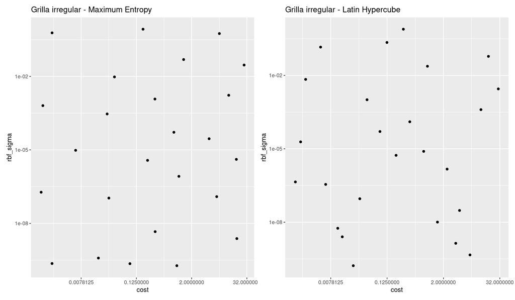

```r
# Grilla "Space-filling designs"
me <- grid_max_entropy(params_svm, size = 25)
lh <- grid_latin_hypercube(params_svm, size = 25)

p1 <- ggplot(me, aes(x = cost, y = rbf_sigma)) +
  geom_point() +
  scale_y_log10() +
  scale_x_continuous(trans = "log2") +
  labs(title = "Grilla irregular - Maximum Entropy")

p2 <- ggplot(lh, aes(x = cost, y = rbf_sigma)) +
  geom_point() +
  scale_y_log10() +
  scale_x_continuous(trans = "log2") +
  labs(title = "Grilla irregular - Latin Hypercube")

p1 + p2
```

Sin un motivo específico, utilizaremos la grilla de máxima entropía.

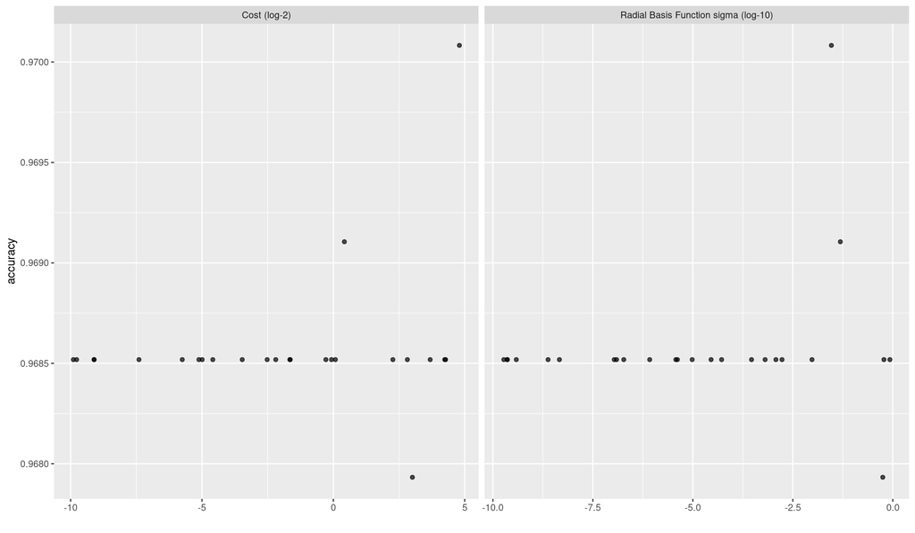

```r
metrics <- yardstick::metric_set(accuracy)

bank_tune <-
  bank_wf %>%
  tune_grid(
    bankruptcy_cv,
    grid = me,
    metrics = metrics
  )

autoplot(bank_tune)
```

```r
# Vemos el parámetro del mejor modelo
select_best(bank_tune, metric = "accuracy")
```

| cost | rbf_sigma | .config |
| --- | --- | --- |
| 27.818 | 0.02914107 | Preprocessor1_Model09 |

```r
# Obtenemos el fit final
bank_f_wf <-
  bank_wf %>%
  finalize_workflow(select_best(bank_tune, metric = "accuracy"))
bank_f_wf
```

```
## ══ Workflow ════════════════════════════════════════════════════════════════════
## Preprocessor: Recipe
## Model: svm_rbf()
##
## ── Preprocessor ────────────────────────────────────────────────────────────────
## 1 Recipe Step
##
## • step_normalize()
##
## ── Model ───────────────────────────────────────────────────────────────────────
## Radial Basis Function Support Vector Machine Model Specification (classification)
##
## Main Arguments:
##   cost = 27.8179996141372
##   rbf_sigma = 0.0291410746231665
##
## Computational engine: kernlab
```

```r
# Ajustamos y predecimos
bank_fit <-
  bank_f_wf %>%
  fit(bankruptcy_train)

bank_predictions <-
  bank_fit %>%
  predict(new_data = bankruptcy_test) %>%
  dplyr::bind_cols(bankruptcy_test) %>%
  dplyr::select(bankrupt, .pred_class)
head(bank_predictions, 10)
```

| bankrupt | .pred_class |
| --- | --- |
| Yes | No |
| No | No |
| No | No |
| No | No |
| No | No |
| No | No |
| No | No |
| No | No |
| No | No |
| No | No |

¿Ocurrirá lo mismo que la vez pasada?

```r
table(bank_predictions$.pred_class)
```

```
##
##  Yes   No
##   10 1695
```

```r
conf_mat(
  data = bank_predictions,
  truth = bankrupt,
  estimate = .pred_class
)
```

```
##           Truth
## Prediction  Yes   No
##        Yes    4    6
##        No    55 1640
```

En este caso hay dos métricas que son más de interés: **precision** y **recall**. Juntamos todo lo anterior en el código a continuación, utilizando ahora estas métricas.

```r
set.seed(219)

# 1. División de los datos
bankruptcy_split <- rsample::initial_split(
  data = bankruptcy,
  strata = bankrupt
)

bankruptcy_train <- rsample::training(bankruptcy_split)
bankruptcy_test <- rsample::testing(bankruptcy_split)
bankruptcy_cv <- rsample::vfold_cv(bankruptcy_train, v = 5, strata = bankrupt)

# 2. Especificación del modelo
bank_model <-
  parsnip::svm_rbf(cost = tune(), rbf_sigma = tune()) %>%
  set_engine("kernlab") %>%
  set_mode("classification")

# 3. Especificación de la receta
bank_recipe <-
  recipes::recipe(bankrupt ~ ., data = bankruptcy_train) %>%
  step_normalize(all_predictors())

# 4. Modelo
bank_wf <-
  workflows::workflow() %>%
  add_model(bank_model) %>%
  add_recipe(bank_recipe)

# Cambio en los valores
params_svm <- parameters(cost(), rbf_sigma())
me <- grid_max_entropy(params_svm, size = 25)
metrics <- yardstick::metric_set(precision, recall)

# Grilla
bank_tune <-
  bank_wf %>%
  tune_grid(
    bankruptcy_cv,
    grid = me,
    metrics = metrics
  )
```

```
## ! Fold1: internal:
##   While computing binary `precision()`, no predicted events were detecte...
##   Precision is undefined in this case, and `NA` will be returned.
##   Note that 32 true event(s) actually occured for the problematic event ...
```

```
## ! Fold2: internal:
##   While computing binary `precision()`, no predicted events were detecte...
##   Precision is undefined in this case, and `NA` will be returned.
##   Note that 36 true event(s) actually occured for the problematic event ...
```

```
## ! Fold3: internal:
##   While computing binary `precision()`, no predicted events were detecte...
##   Precision is undefined in this case, and `NA` will be returned.
##   Note that 32 true event(s) actually occured for the problematic event ...
```

```
## ! Fold4: internal:
##   While computing binary `precision()`, no predicted events were detecte...
##   Precision is undefined in this case, and `NA` will be returned.
##   Note that 33 true event(s) actually occured for the problematic event ...
```

```
## ! Fold5: internal:
##   While computing binary `precision()`, no predicted events were detecte...
##   Precision is undefined in this case, and `NA` will be returned.
##   Note that 28 true event(s) actually occured for the problematic event ...
```

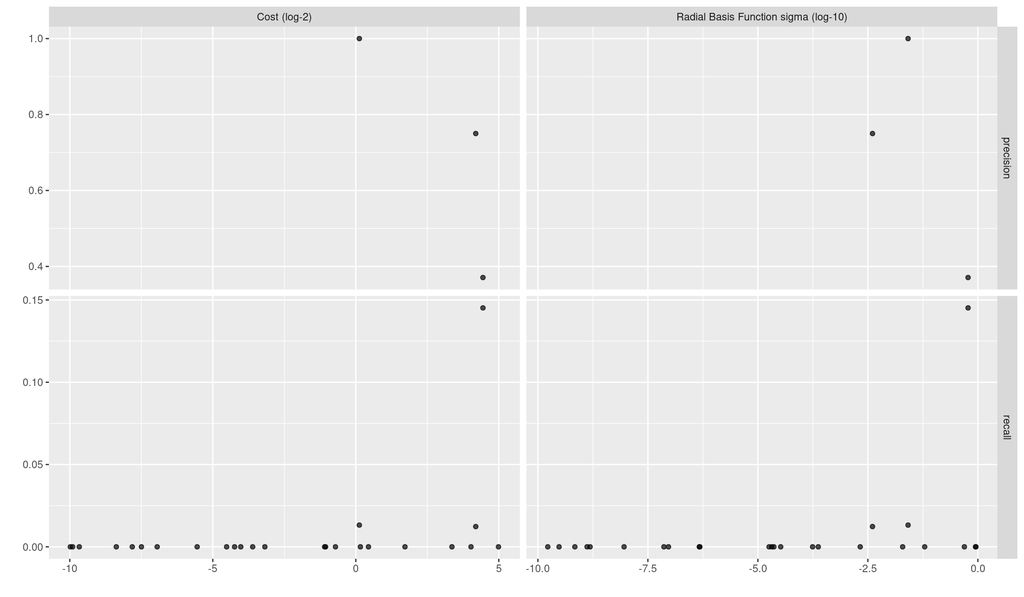

```r
autoplot(bank_tune)
```

```r
# Vemos el parámetro del mejor modelo
select_best(bank_tune, metric = "recall")
```

| cost | rbf_sigma | .config |
| --- | --- | --- |
| 21.78316 | 0.5991604 | Preprocessor1_Model21 |

```r
# Obtenemos el fit final
bank_f_wf <-
  bank_wf %>%
  finalize_workflow(select_best(bank_tune, metric = "recall"))
bank_f_wf
```

```
## ══ Workflow ════════════════════════════════════════════════════════════════════
## Preprocessor: Recipe
## Model: svm_rbf()
##
## ── Preprocessor ────────────────────────────────────────────────────────────────
## 1 Recipe Step
##
## • step_normalize()
##
## ── Model ───────────────────────────────────────────────────────────────────────
## Radial Basis Function Support Vector Machine Model Specification (classification)
##
## Main Arguments:
##   cost = 21.7831585725561
##   rbf_sigma = 0.599160435820719
##
## Computational engine: kernlab
```

```r
# Ajustamos y predecimos
bank_fit <-
  bank_f_wf %>%
  fit(bankruptcy_train)

bank_predictions <-
  bank_fit %>%
  predict(new_data = bankruptcy_test) %>%
  dplyr::bind_cols(bankruptcy_test) %>%
  dplyr::select(bankrupt, .pred_class)
head(bank_predictions, 10)
```

| bankrupt | .pred_class |
| --- | --- |
| Yes | No |
| No | No |
| No | No |
| No | No |
| No | No |
| No | No |
| No | No |
| No | No |
| No | No |
| No | No |

```r
conf_mat(
  data = bank_predictions,
  truth = bankrupt,
  estimate = .pred_class
)
```

```
##           Truth
## Prediction  Yes   No
##        Yes   11   15
##        No    48 1631
```

**Repitan lo mismo con `rbf_poly`**

# Discusión: problemas multiclase